# Example 15: Intext Table

This example produces both stand-alone and “intext” versions of a simple demographics summary table. The stand-alone version is created in PDF and contains page header and footer information. Also, the titles are in the body of the table. The “intext” version is created in RTF and the page headers and footers have been removed. Additionally, the titles have been moved to the page header. The purpose of this arrangement is so that the table can be easily copied to another document for medical writing.

## Program

Note the following about this example:

- Formats are created with the `as.factor = TRUE` parameter to allow non-alphabetic sorting and to show all frequency categories.
- The analysis is the same for both stand-alone and “intext” reports.
- Separate reporting calls are performed for each version of the report to comply with the different layout requirements.
- The `continuous = TRUE` parameter has been set on the “intext” table to create one continuous table instead of separate tables for each page.

```r
library(sassy)

# Prepare Log -------------------------------------------------------------


options("logr.autolog" = TRUE,
        "logr.on" = TRUE,
        "logr.notes" = FALSE,
        "procs.print" = FALSE)

# Get temp directory
tmp <- tempdir()

# Open log
lf <- log_open(file.path(tmp, "example15.log"))


# Prepare formats ---------------------------------------------------------

sep("Prepare formats")

put("Age categories")
agecat <- value(condition(is.na(x), "Missing", 5),
                condition(x >= 18 & x <= 29, "18 to 29", 1),
                condition(x >=30 & x <= 39, "30 to 39", 2),
                condition(x >=40 & x <=49, "40 to 49", 3),
                condition(x >= 50, ">= 50", 4),
                as.factor = TRUE)

put("Sex decodes")
fmt_sex <- value(condition(is.na(x), "Missing", 4),
                 condition(x == "M", "Male", 1),
                 condition(x == "F", "Female", 2),
                 condition(TRUE, "Other", 3),
                 as.factor = TRUE)

put("Race decodes")
fmt_race <- value(condition(is.na(x), "Missing", 5),
                  condition(x == "WHITE", "White", 1),
                  condition(x == "BLACK OR AFRICAN AMERICAN", "Black or African American", 2),
                  condition(x == "ASIAN", "Asian or Pacific Islander", 3),
                  condition(TRUE, "Unkown", 4),
                  as.factor = TRUE)

put("Ethnic decodes")
fmt_ethnic <- value(condition(is.na(x), "Missing", 4),
                    condition(x == "HISPANIC OR LATINO", "Hispanic or Latino", 1),
                    condition(x == "NOT HISPANIC OR LATINO", "Not Hispanic or Latino", 2),
                    condition(x == "UNKNOWN", "Unknown", 3),
                    as.factor = TRUE)

put("ARM decodes")
fmt_arm <- value(condition(x == "ARM A", "Placebo"),
                 condition(x == "ARM B", "Drug 10mg"),
                 condition(x == "ARM C", "Drug 20mg"),
                 condition(x == "ARM D", "Competitor"))

put("Compile format catalog")
fc <- fcat(MEAN = "%.1f", STD = "(%.2f)",
           Q1 = "%.1f", Q3 = "%.1f",
           MIN = "%d", MAX = "%d",
           CNT = "%2d", PCT = "(%5.1f%%)")


# Load and Prepare Data ---------------------------------------------------

sep("Prepare Data")

# Get sample data path
pth <- system.file("extdata", package = "sassy")

put("Open data library")
libname(sdtm, pth, "csv")

put("Extract DM dataset")
datdm <- subset(sdtm$DM, ARM != 'SCREEN FAILURE')

put("Apply formats")
datdm$AGECAT <- fapply(datdm$AGE, agecat)
datdm$SEXF <- fapply(datdm$SEX, fmt_sex)
datdm$RACEF <- fapply(datdm$RACE, fmt_race)
datdm$ARMF <- fapply(datdm$ARM, fmt_arm)
datdm$ETHNICF <- fapply(datdm$ETHNIC, fmt_ethnic)

put("Get ARM population counts")
proc_freq(datdm, tables = ARM,
          output = long,
          options = v(nopercent, nonobs)) -> arm_pop

# Age Summary Block -------------------------------------------------------

sep("Create summary statistics for age")

put("Call means procedure to get summary statistics for age")
proc_means(datdm, var = AGE,
           stats = v(n, mean, std, median, q1, q3, min, max),
           by = ARM,
           options = v(notype, nofreq)) -> age_stats

put("Combine stats")
datastep(age_stats,
         format = fc,
         drop = find.names(age_stats, start = 4),
         {
           `Mean (SD)` <- fapply2(MEAN, STD)
           Median <- MEDIAN
           `Q1 - Q3` <- fapply2(Q1, Q3, sep = " - ")
           `Min - Max` <- fapply2(MIN, MAX, sep = " - ")


         }) -> age_comb

put("Transpose ARMs into columns")
proc_transpose(age_comb,
               var = names(age_comb),
               copy = VAR, id = BY,
               name = LABEL) -> age_block


# Age Group Block ----------------------------------------------------------

sep("Create frequency counts for Age Group")


put("Get age group frequency counts")
proc_freq(datdm,
          table = AGECAT,
          by = ARM,
          options = nonobs) -> ageg_freq

put("Combine counts and percents and assign age group factor for sorting")
datastep(ageg_freq,
         format = fc,
         keep = v(VAR, LABEL, BY, CNTPCT),
         {
           CNTPCT <- fapply2(CNT, PCT)
           LABEL <- CAT
         }) -> ageg_comb

put("Tranpose age group block")
proc_transpose(ageg_comb,
               var = CNTPCT,
               copy = VAR,
               id = BY,
               by = LABEL,
               options = noname) -> ageg_block

# Sex Block ---------------------------------------------------------------

sep("Create frequency counts for SEX")

put("Get sex frequency counts")
proc_freq(datdm, tables = SEXF,
          by = ARM,
          options = nonobs) -> sex_freq


put("Combine counts and percents.")
datastep(sex_freq,
         format = fc,
         rename = list(CAT = "LABEL"),
         drop = v(CNT, PCT),
         {

           CNTPCT <- fapply2(CNT, PCT)

         }) -> sex_comb

put("Transpose ARMs into columns")
proc_transpose(sex_comb, id = BY,
               var = CNTPCT,
               copy = VAR, by = LABEL,
               options = noname) -> sex_block


# Race block --------------------------------------------------------------


sep("Create frequency counts for RACE")

put("Get race frequency counts")
proc_freq(datdm, tables = RACEF,
          by = ARM,
          options = nonobs) -> race_freq


put("Combine counts and percents.")
datastep(race_freq,
         format = fc,
         rename = list(CAT = "LABEL"),
         drop = v(CNT, PCT),
         {

           CNTPCT <- fapply2(CNT, PCT)

         }) -> race_comb

put("Transpose ARMs into columns")
proc_transpose(race_comb, id = BY, var = CNTPCT,
               copy = VAR, by = LABEL,
               options = noname) -> race_block





# Ethnic Block ---------------------------------------------------------------

sep("Create frequency counts for ETHNIC")

put("Get ethnic frequency counts")
proc_freq(datdm, tables = ETHNICF,
          by = ARM,
          options = nonobs) -> ethnic_freq

put("Combine counts and percents.")
datastep(ethnic_freq, format = fc,
         rename = list(CAT = "LABEL"),
         drop = v(CNT, PCT),
         {
           CNTPCT <- fapply2(CNT, PCT)
         }) -> ethnic_comb

put("Transpose ARMs into columns")
proc_transpose(ethnic_comb, id = BY,
               var = CNTPCT,
               copy = VAR, by = LABEL,
               options = noname) -> ethnic_block


# Prepare final dataset ---------------------------------------------------

put("Combine blocks into final data frame")
datastep(age_block,
         set = list(ageg_block, sex_block, race_block, ethnic_block),
         {}) -> final

# Report ------------------------------------------------------------------


var_fmt <- c("AGE" = "Age", "AGECAT" = "Age Group", "SEXF" = "Sex",
             "RACEF" = "Race", "ETHNICF" = "Ethnicity")

sep("Create and print stand-alone report")

# Create Table
tbl1 <- create_table(final, first_row_blank = TRUE) |>
  column_defaults(from = `ARM A`, to = `ARM D`, align = "center", width = 1.1) |>
  stub(vars = c("VAR", "LABEL"), "Variable", width = 2.5) |>
  define(VAR, blank_after = TRUE, dedupe = TRUE, label = "Variable",
         format = var_fmt,label_row = TRUE) |>
  define(LABEL, indent = .25, label = "Demographic Category") |>
  define(`ARM A`,  label = "Placebo", n = arm_pop["ARM A"]) |>
  define(`ARM B`,  label = "Drug 50mg", n = arm_pop["ARM B"]) |>
  define(`ARM C`,  label = "Drug 100mg", n = arm_pop["ARM C"]) |>
  define(`ARM D`,  label = "Competitor", n = arm_pop["ARM D"]) |>
  titles("Table 1.0", "Analysis of Demographic Characteristics",
         "Safety Population", bold = TRUE) |>
  footnotes("Program: DM_Table.R",
            "NOTE: Denominator based on number of non-missing responses.",
            valign = "bottom", align = "left")

rpt1 <- create_report(file.path(tmp, "example15s"),
                     output_type = "PDF",
                     font = "Courier") |>
  page_header(c("Sponsor: Company", "Study: ABC"),
              right = c("DRUG: XYZ", "LOCK DATE: 02FEB2024")) |>
  set_margins(top = 1, bottom = 1) |>
  add_content(tbl1) |>
  page_footer("Date Produced: {Sys.Date()}", right = "Page [pg] of [tpg]")

put("Write out the report")
res1 <- write_report(rpt1)


sep("Create and print intext report")

# Create Table
tbl2 <- create_table(final, first_row_blank = TRUE, continuous = TRUE,
                     borders = c("top"), width = 6.5) |>
  column_defaults(from = `ARM A`, to = `ARM D`, align = "center", width = 1.1) |>
  stub(vars = c("VAR", "LABEL"), "Variable") |>
  define(VAR, blank_after = TRUE, dedupe = TRUE, label = "Variable",
         format = var_fmt,label_row = TRUE) |>
  define(LABEL, indent = .25, label = "Demographic Category") |>
  define(`ARM A`,  label = "Placebo", n = arm_pop["ARM A"]) |>
  define(`ARM B`,  label = "Drug 50mg", n = arm_pop["ARM B"]) |>
  define(`ARM C`,  label = "Drug 100mg", n = arm_pop["ARM C"]) |>
  define(`ARM D`,  label = "Competitor", n = arm_pop["ARM D"]) |>

  footnotes("Program: DM_Table.R",
            "NOTE: Denominator based on number of non-missing responses.",
            borders = c("top", "bottom"), blank_row = "none")

rpt2 <- create_report(file.path(tmp, "example15i"),
                     output_type = "RTF",
                     font = "Arial", orientation = "landscape") |>
  set_margins(top = 1, bottom = 1) |>
  add_content(tbl2) |>
  titles("Table 1.0", "Analysis of Demographic Characteristics",
         "Safety Population", bold = TRUE, header = TRUE)


put("Write out the report")
res2 <- write_report(rpt2)

# Clean Up ----------------------------------------------------------------
sep("Clean Up")

put("Close log")
log_close()


# Uncomment to view report
# file.show(res1$modified_path)

# Uncomment to view report
# file.show(res2$modified_path)

# Uncomment to view log
# file.show(lf)
```

## Output

Here is the stand-alone report:

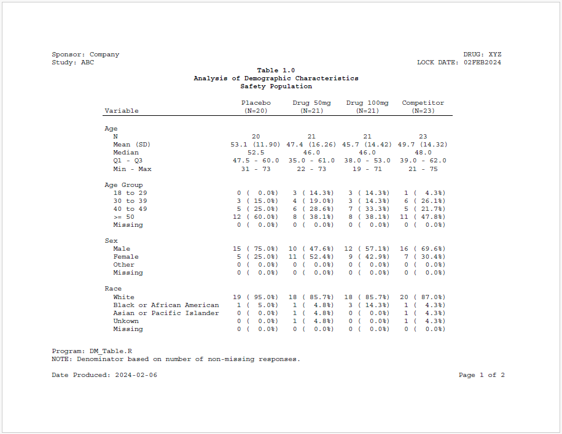

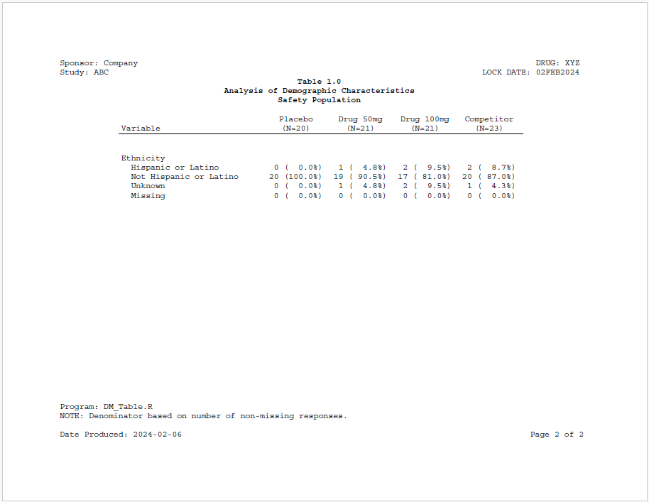

Here is the “intext” report:

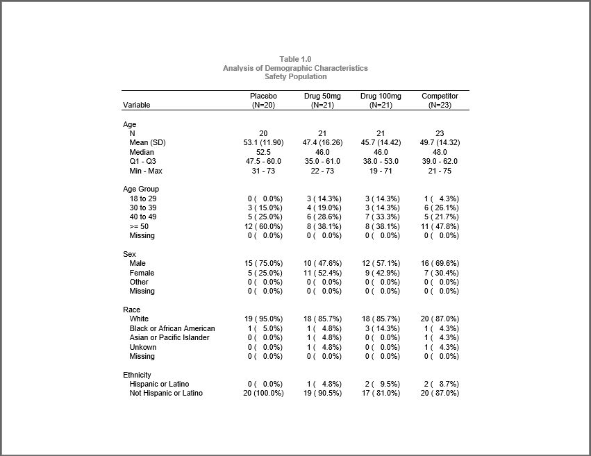

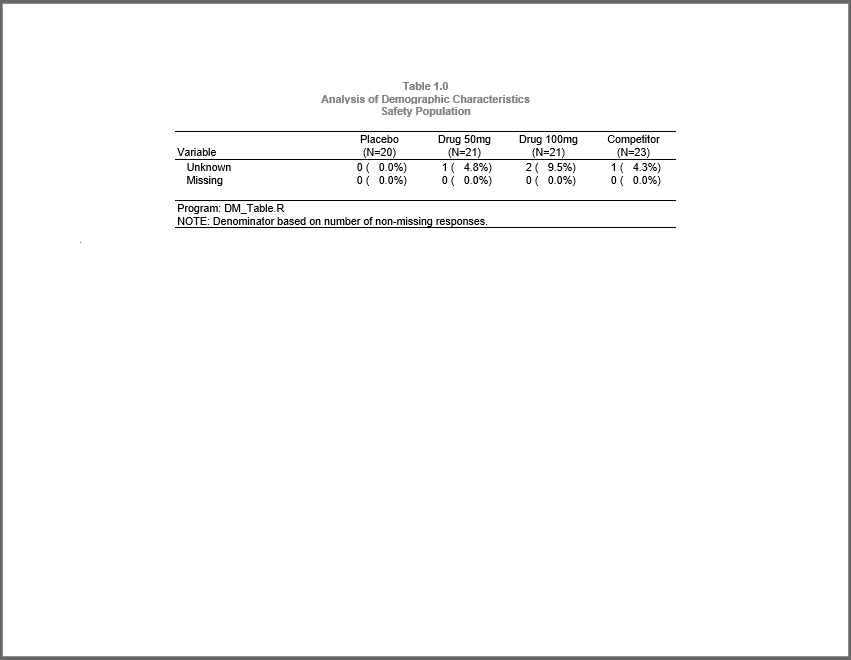

## Log

And here is the log:

```
=========================================================================
Log Path: C:/Users/dbosa/AppData/Local/Temp/RtmpiOUehg/log/example15.log
Program Path: C:/packages/Testing/sassytests/Intext.R
Working Directory: C:/packages/Testing
User Name: dbosa
R Version: 4.3.2 (2023-10-31 ucrt)
Machine: SOCRATES x86-64
Operating System: Windows 10 x64 build 22621
Base Packages: stats graphics grDevices utils datasets methods base
Other Packages: tidylog_1.0.2 procs_1.0.5 reporter_1.4.4 libr_1.2.9 logr_1.3.5
fmtr_1.6.2 common_1.1.1 sassy_1.2.1
Log Start Time: 2024-02-03 13:05:46.15931
=========================================================================

=========================================================================
Prepare formats
=========================================================================

Age categories

# A user-defined format: 5 conditions
- as.factor: TRUE
  Name Type        Expression    Label Order
1  obj    U          is.na(x)  Missing     5
2  obj    U x >= 18 & x <= 29 18 to 29     1
3  obj    U x >= 30 & x <= 39 30 to 39     2
4  obj    U x >= 40 & x <= 49 40 to 49     3
5  obj    U           x >= 50    >= 50     4

Sex decodes

# A user-defined format: 4 conditions
- as.factor: TRUE
  Name Type Expression   Label Order
1  obj    U   is.na(x) Missing     4
2  obj    U   x == "M"    Male     1
3  obj    U   x == "F"  Female     2
4  obj    U       TRUE   Other     3

Race decodes
```

[output cut: 520 more lines]

```
- define: ARM A 'Placebo'
- define: ARM B 'Drug 50mg'
- define: ARM C 'Drug 100mg'
- define: ARM D 'Competitor'

=========================================================================
Clean Up
=========================================================================

Close log

=========================================================================
Log End Time: 2024-02-03 13:05:49.136026
Log Elapsed Time: 0 00:00:02
=========================================================================
```